JUNGHYUN YANG

# Geospatial_02_exercise

Sep 26, 2022 • 6 min read

```python
import pandas as pd
import geopandas as gpd

from shapely.geometry import LineString

from learntools.core import binder
binder.bind(globals())
from learntools.geospatial.ex2 import *
```

### 1) 데이터를 로드합니다.

다음 코드 셀(변경 없이)을 실행하여 GPS 데이터를 팬더 데이터 프레임 'birds_df'에 로드합니다.

```python
birds_df = pd.read_csv("data/purple_martin.csv", parse_dates=['timestamp'])
print("There are {} different birds in the dataset.".format(birds_df["tag-local-identifier"].nunique()))
birds_df.head()
```

```
There are 11 different birds in the dataset.
```

|  | timestamp | location-long | location-lat | tag-local-identifier |
| --- | --- | --- | --- | --- |
| 0 | 2014-08-15 05:56:00 | -88.146014 | 17.513049 | 30448 |
| 1 | 2014-09-01 05:59:00 | -85.243501 | 13.095782 | 30448 |
| 2 | 2014-10-30 23:58:00 | -62.906089 | -7.852436 | 30448 |
| 3 | 2014-11-15 04:59:00 | -61.776826 | -11.723898 | 30448 |
| 4 | 2014-11-30 09:59:00 | -61.241538 | -11.612237 | 30448 |

데이터 세트에는 11개의 새가 있으며, 각 새는 "태그-로컬-식별자" 열의 고유한 값으로 식별된다. 각 새들은 일 년 중 다른 시간에 수집되는 몇 가지 치수를 가지고 있다.

다음 코드 셀을 사용하여 GeoDataFrame "birds"를 만듭니다.

- birds는 birds_df의 모든 열과 (경도, 위도) 위치의 점 객체를 포함하는 "기하학" 열을 가져야 한다.
- 'birds'의 CRS를 '{'init''로 설정합니다. 'epsg:4326'}?

```python
birds = gpd.GeoDataFrame(birds_df, geometry=gpd.points_from_xy(birds_df["location-long"], birds_df["location-lat"]))

# Your code here: Set the CRS to {'init': 'epsg:4326'}
birds.crs = {'init' :'epsg:4326'}

# Check your answer
q_1.check()
```

Correct

### 2) 데이터를 표시합니다.

그런 다음 GeoPandas에서 'natural earth_lowres' 데이터 세트를 로드하고, '아메리카'를 미주(북미 및 남미)의 모든 국가의 경계를 포함하는 GeoDataFrame으로 설정한다. 변경 사항 없이 다음 코드 셀을 실행합니다.

```python
world = gpd.read_file(gpd.datasets.get_path('naturalearth_lowres'))
americas = world.loc[world['continent'].isin(['North America', 'South America'])]
americas.head()
```

|  | pop_est | continent | name | iso_a3 | gdp_md_est | geometry |
| --- | --- | --- | --- | --- | --- | --- |
| 3 | 35623680 | North America | Canada | CAN | 1674000.0 | MULTIPOLYGON (((-122.84000 49.00000, -122.9742... |
| 4 | 326625791 | North America | United States of America | USA | 18560000.0 | MULTIPOLYGON (((-122.84000 49.00000, -120.0000... |
| 9 | 44293293 | South America | Argentina | ARG | 879400.0 | MULTIPOLYGON (((-68.63401 -52.63637, -68.25000... |
| 10 | 17789267 | South America | Chile | CHL | 436100.0 | MULTIPOLYGON (((-68.63401 -52.63637, -68.63335... |
| 16 | 10646714 | North America | Haiti | HTI | 19340.0 | POLYGON ((-71.71236 19.71446, -71.62487 19.169... |

다음 코드 셀을 사용하여 (1) "아메리카" GeoDataFrame의 국가 경계와 (2) "birds_gdf" GeoDataFrame의 모든 점을 보여주는 단일 그래프를 만듭니다.

여기서는 특별한 스타일링에 대해 걱정할 필요 없이 모든 데이터가 올바르게 로드되었는지 신속하게 확인하기 위해 예비 플롯을 생성하기만 하면 됩니다. 특히 새를 구분하기 위해 포인트를 컬러 코딩할 염려도 없고, 시작 포인트와 끝 포인트를 구분할 필요도 없다. 우리는 연습의 다음 부분에서 그것을 할 것이다.

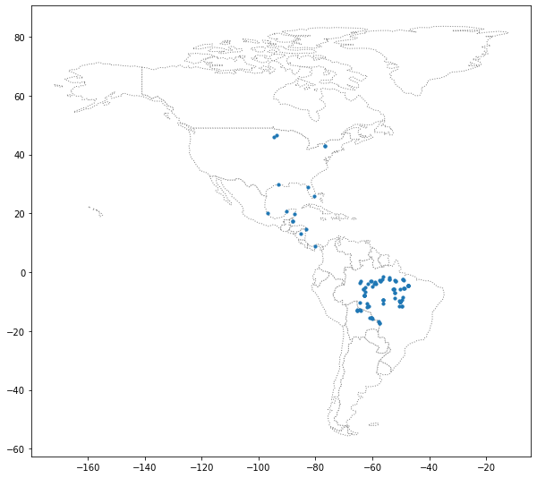

```python
ax = americas.plot(figsize=(10,10), color='white', linestyle=':', edgecolor='gray')
birds.plot(ax=ax, markersize=10)
```

```python
q_2.check()
```

Thank you for creating a map!

### 3) 각각의 새는 어디에서 출발하고 그 여정을 끝냅니까? (1부)

이제, 우리는 각각의 새들의 길을 더 자세히 볼 준비가 되었습니다. 다음 코드 셀을 실행하여 두 개의 GeoDataFrame을 생성합니다.

- 'path_gdf'에는 각 버드의 경로를 보여주는 LineString 개체가 포함되어 있습니다. LineString() 메서드를 사용하여 Point 객체 목록에서 LineString 객체를 생성합니다.
- 'start_gdf'에는 각 새의 시작점이 포함되어 있습니다.

```python
path_df = birds.groupby("tag-local-identifier")['geometry'].apply(list).apply(lambda x: LineString(x)).reset_index()
path_gdf = gpd.GeoDataFrame(path_df, geometry=path_df.geometry)
path_gdf.crs = {'init' :'epsg:4326'}

# GeoDataFrame showing starting point for each bird
start_df = birds.groupby("tag-local-identifier")['geometry'].apply(list).apply(lambda x: x[0]).reset_index()
start_gdf = gpd.GeoDataFrame(start_df, geometry=start_df.geometry)
start_gdf.crs = {'init' :'epsg:4326'}

# Show first five rows of GeoDataFrame
start_gdf.head()
```

|  | tag-local-identifier | geometry |
| --- | --- | --- |
| 0 | 30048 | POINT (-90.12992 20.73242) |
| 1 | 30054 | POINT (-93.60861 46.50563) |
| 2 | 30198 | POINT (-80.31036 25.92545) |
| 3 | 30263 | POINT (-76.78146 42.99209) |
| 4 | 30275 | POINT (-76.78213 42.99207) |

다음 코드 셀을 사용하여 각 버드의 최종 위치를 포함하는 GeoDataFrame 'end_gdf'를 만듭니다.

- 형식은 "tag-local-identifier" 및 "geometry" 열에서 점 객체를 포함하는 두 개의 열("tag-local-identifier")과 "start_gdf"의 형식과 동일해야 한다.
- 'end_gdf'의 CRS를 '{'init'로 설정합니다. 'epsg:4326'}:

```python
end_df = birds.groupby("tag-local-identifier")['geometry'].apply(list).apply(lambda x: x[-1]).reset_index()
end_gdf = gpd.GeoDataFrame(end_df, geometry=end_df.geometry)
end_gdf.crs = {'init': 'epsg:4326'}

# Check your answer
q_3.check()
```

Correct

### 4) 각각의 새는 어디에서 출발하고 그 여정을 끝냅니까? (2부)

위 질문('path_gdf', 'start_gdf', 'end_gdf')의 GeoDataFrames를 사용하여 모든 새의 경로를 단일 지도에서 시각화한다. 또한 "아메리카" GeoDataFrame을 사용할 수도 있습니다.

Thank you for creating a map!

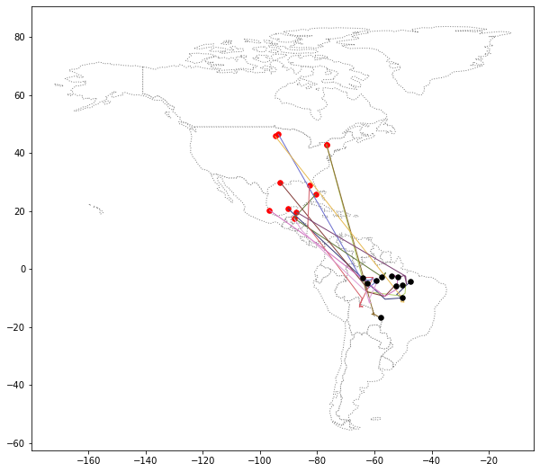

```python
ax = americas.plot(figsize=(10, 10), color='white', linestyle=':', edgecolor='gray')

start_gdf.plot(ax=ax, color='red',  markersize=30)
path_gdf.plot(ax=ax, cmap='tab20b', linestyle='-', linewidth=1, zorder=1)
end_gdf.plot(ax=ax, color='black', markersize=30)

# Uncomment to see a hint
#_COMMENT_IF(PROD)_
# Get credit for your work after you have created a map
q_4.check()
```

### 5) 남아메리카의 보호 구역은 어디인가? (1부)

모든 새들은 결국 남아메리카의 어딘가에 있는 것처럼 보입니다. 하지만 그들은 보호구역으로 갈까요?

다음 코드 셀에서는 남아메리카에 있는 모든 보호 지역의 위치를 포함하는 GeoDataFrame "protected_areas"를 만듭니다. 해당 셰이프 파일은 파일 경로 'protected_filepath'에 있습니다.

```python
protected_filepath = "data/SAPA_Aug2019-shapefile/SAPA_Aug2019-shapefile/SAPA_Aug2019-shapefile-polygons.shp"

# Your code here
protected_areas = gpd.read_file(protected_filepath)

# Check your answer
q_5.check()
```

Correct

### 6) 남아메리카의 보호 구역은 어디인가? (2부)

'protected_areas' GeoDataFrame을 사용하여 남미에서 보호 지역의 위치를 표시하는 그래프를 만듭니다. (*여러분은 어떤 보호 구역은 육지에 있고 다른 보호 구역은 해양에 있다는 것을 알게 될 것입니다.*)

Thank you for creating a map!

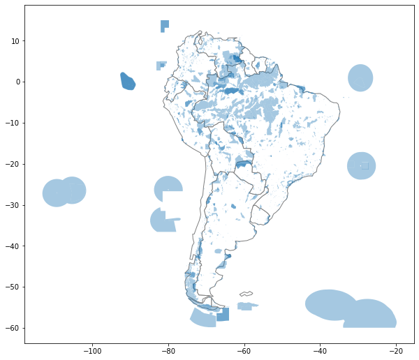

```python
south_america = americas.loc[americas['continent']=='South America']

# Your code here: plot protected areas in South America
ax = south_america.plot(figsize=(10,10), color='white', edgecolor='gray')
protected_areas.plot(ax=ax, alpha=0.4)

# Uncomment to see a hint
# Get credit for your work after you have created a map
q_6.check()
```

### 7) 남아메리카의 몇 퍼센트가 보호되고 있나요?

여러분은 남아메리카의 몇 퍼센트가 보호되고 있는지 알아내는 것에 관심이 있습니다. 그래서 여러분은 남아메리카의 얼마나 많은 부분이 새들에게 적합한지 알 수 있습니다.

첫 번째 단계로 남아메리카에 있는 모든 보호 토지의 총 면적(해상 면적은 제외)을 계산합니다. 이렇게 하려면 "REP_AREA" 열과 "REP_M_AREA" 열을 사용합니다. 이 열에는 총 면적과 총 해양 면적이 각각 제곱 킬로미터 단위로 포함됩니다.

아래의 코드 셀을 변경하지 않고 실행합니다.

```python
P_Area = sum(protected_areas['REP_AREA']-protected_areas['REP_M_AREA'])
print("South America has {} square kilometers of protected areas.".format(P_Area))
```

```
South America has 5396761.9116883585 square kilometers of protected areas.
```

Then, to finish the calculation, you'll use the `south_america` GeoDataFrame.

```python
south_america.head()
```

|  | pop_est | continent | name | iso_a3 | gdp_md_est | geometry |
| --- | --- | --- | --- | --- | --- | --- |
| 9 | 44293293 | South America | Argentina | ARG | 879400.0 | MULTIPOLYGON (((-68.63401 -52.63637, -68.25000... |
| 10 | 17789267 | South America | Chile | CHL | 436100.0 | MULTIPOLYGON (((-68.63401 -52.63637, -68.63335... |
| 20 | 2931 | South America | Falkland Is. | FLK | 281.8 | POLYGON ((-61.20000 -51.85000, -60.00000 -51.2... |
| 28 | 3360148 | South America | Uruguay | URY | 73250.0 | POLYGON ((-57.62513 -30.21629, -56.97603 -30.1... |
| 29 | 207353391 | South America | Brazil | BRA | 3081000.0 | POLYGON ((-53.37366 -33.76838, -53.65054 -33.2... |

다음 단계에 따라 남아메리카의 총 면적을 계산합니다.

- 각 다각형(EPSG 3035를 CRS로 하여)의 '면적' 속성을 이용하여 각국의 면적을 계산하고 그 결과를 합산한다. 계산된 면적은 제곱미터 단위로 표시됩니다.
- 답을 제곱 킬로미터 단위로 변환합니다.

```python
totalArea = sum(south_america.geometry.to_crs(epsg=3035).area) / 10**6

# Check your answer
q_7.check()
```

Correct

아래의 코드 셀을 실행하여 보호되는 남아메리카의 비율을 계산하십시오.

```python
percentage_protected = P_Area/totalArea
print('Approximately {}% of South America is protected.'.format(round(percentage_protected*100, 2)))
```

```
Approximately 30.39% of South America is protected.
```

### 8) 남아메리카의 새들은 어디에 있나요?

그렇다면, 그 새들은 보호 구역에 있을까요?

남아메리카에서 발견된 모든 새의 위치를 보여주는 그래프를 만듭니다. 또한 남아메리카에 있는 모든 보호 구역의 위치를 표시합니다.

Thank you for creating a map!

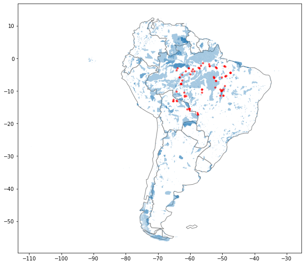

```python
ax = south_america.plot(figsize=(10,10), color='white', edgecolor='gray')
protected_areas[protected_areas['MARINE']!='2'].plot(ax=ax, alpha=0.4, zorder=1)
birds[birds.geometry.y < 0].plot(ax=ax, color='red', alpha=0.6, markersize=10, zorder=2)

# Get credit for your work after you have created a map
q_8.check()
```

# Keep going

Create stunning **interactive maps** with your geospatial data.